# UCANR Statistics Workshop Series Planning Survey

November 09, 2021

# Introduction

This report summarizes the responses from a survey sent to CE Advisors in October ’21 for the purposes of planning a series of statistics workshops in early 2022. The number of reponses was 36. For details please contact Jodi Azulai.

# Learning goals

### Please rank the importance to you of each of the following learning goals.

Generally refresh or update my statistics skills

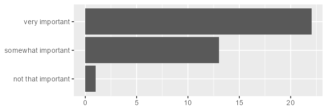

Explore what I can do with data I already have

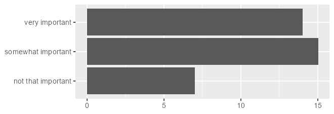

Strengthen skills in cleaning and manipulating data

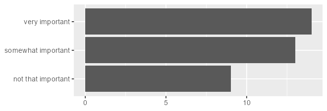

Learn how to use specific statistical methods, models, or tests

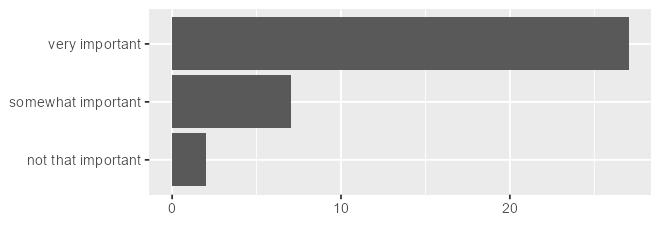

Strengthen skills in research design and sampling

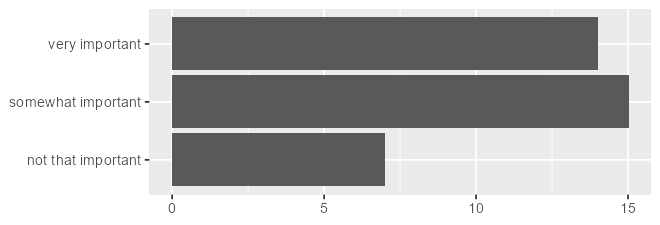

Improve my skills in using R

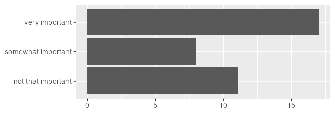

Other (describe below)

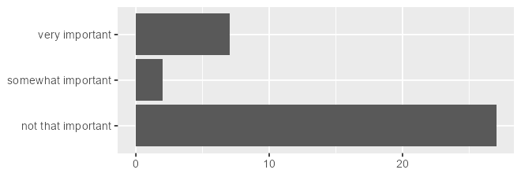

Comments

- How many reps do I need for my trial?
- Spss or if R is better I’m okay w it too, but would have to learn it completely.
- multivariate statistics linking different data types to see correlations and do modeling
- I am particularly interested in regression modeling, refreshing my understanding of how to determine the quality of data, and would be interested in learning more about how to evaluate aerial spatial data.
- Interpreting statistical outputs, what is important to look for, how to deal with missing data, transformations, non parametric statistics
- Are there new preferred mean separation tests (I mostly use Tukey)? How to do mean separation with split plot design? *Who of the younger campus faculty is good at what statistics, so we aren’t haranguing Emilio if/when he retires?*
- comparison of statistical programs available
- Learn if the university provides access to statistical programs or learn which one to purchase
- N/A
- It would be useful to review methods for determining data normality and what to do when data isn’t normally distributed. Maybe also cover typical experimental designs in ag and the most common statistical analysis types.

Which of the following topics or analyses are you most interested in learning about?

Select all that apply.

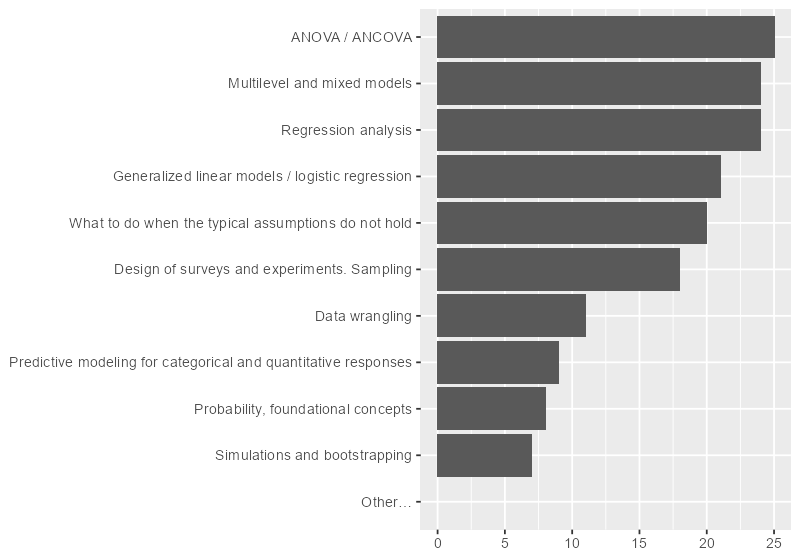

Other:

- Mean separation after ANOVA as found significant difference.

# Users’ Projects and Data

Do you have a specific project or dataset that you want to work on?

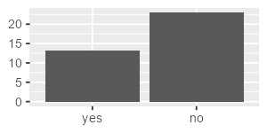

If yes, please briefly describe the project or dataset you want to work on.

- rodent activity
- Three years split block design
- Local county EFNEP data
- wild horse presence from trail cameras
- Youth retention study
- Defensible space assessment data for 400 homes, half of which burned in the Angora fire and were rebuilt and half of which didn’t burn. I’m comparing their vegetation.
- Survey of ground, drone, and satellite images over long time course
- Nematicide screening data
- Split plot - Main treatment effect is whether walnut trees were heated or not during winter to either meet their winter chill requirement or not. Sub-plot is different dormancy breaking chemicals to try to overcome insufficient winter chill. I can do the ANOVA but stall out after that on mean separation options. I’m working with Dr Z on this project. This is an example, but I generally want to be able to use split plot more in my experimental designs instead of always RCBD, so this is a problem to solve but also a learning tool for me, so I don’t want to just have Maciej run some code for me.
- A large dataset with various measures on honey bee colony strength and pest numbers, measured over time (measures taken every 5 to 6 weeks for about a year). Colonies were placed in multiple locations and had a variety of “treatments” applied.
- Split-split plot design 3x3x6 (replicated 3x), multi-year, yield and tissue N content data
- I want to measure the effect of a plant hormone on budbrake and if advances maturity and sugar content on table grapes
- soil health project

If yes, what are the primary question(s) you want to answer with your data and statistics?

- Does rodent activity vary with different treatments
- Which model to use and how to run ANOVA
- Impact and Outcomes of Program
- differences in use of springs by horses verse cattle or wildlife
- How well do homes rebuilt after fire follow best practices for defensible space? How does this compare to homes that never burned? How much has vegetation type planted after fire changed compared to vegetation around homes that didn’t burn? (life form - tree, shrub, herbaceous) (species - conifer, deciduous, native, landscape/non native
- What can be said from the data? How best can the data be analyzed?
- transformation and interpretation of output
- Which dormancy breaking treatments (sub-plot) are effective (at, for example, changing bud break timing)? Are some more effective (change bud break timing more) than others? To what extent does dormancy breaking treatments effectiveness change when trees have not experienced sufficient winter chill? ANOVA has told me heat/not, chemical treatment/not and heat*chemical are significant, but I want to know how the treatments separate out.
- Impact of supplemental forage on colony health.
- I do not have enough replicates of experimental units within blocks to assign all fixed and random factors within the design df in the analytical model. How do I examine data to determine what factors to pool/exclude from the model to have a robust analysis of important factors?
- I want to determine if the plant hormone can substitute the use of a conventional highly toxic material
- How to use stepwise regression or PCA to show how different soil health properties differentiate irrigation treatments.

If yes, are you working with other Advisors on this project?

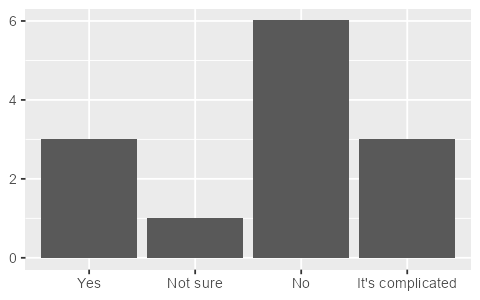

# Software Experience

Which of the following stats software do you currently use or have experience with?

Select all that apply.

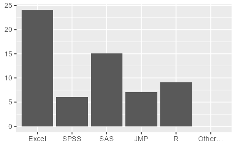

Other:

- InfoStat
- Statistix
- SPSS was a long time ago
- Statgraphics
- MSTAT
- NA
- CoStat
- STATA

What is your background in R?

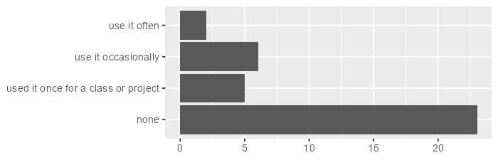

If you don’t use R, do you have coding experience in any other language?

Pick one.

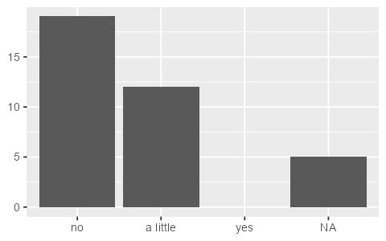

If you’re interested in specific R package(s), or how to do specific test(s) in R, please describe briefly.

- I want to learn how to code R to run statistics
- dplyr
- Just need general understanding, starting with zero
- MANOVAs and other multivariate statistics such as PCA, MFA, CVA
- Would prefer wholesale transfer of statistical analyses from SPSS to R. Typical analyses include all descriptive (including graphing) and assumptions testing for ANOVA, Regression.
- ANOVA, regression

How would you like hands-on practice / homework to be incorporated in the course?

Select all that apply.

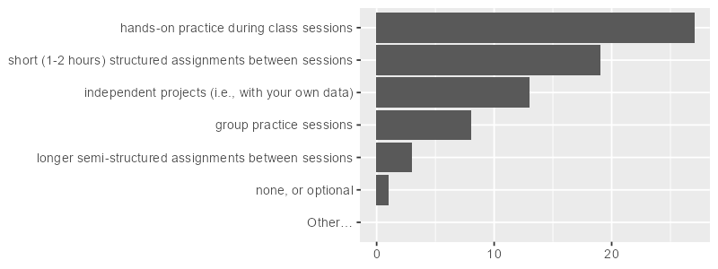

# Other Questions

Would you be interested in consulting with someone for ~15 minutes before the course about your specific learning goals, project, or dataset?

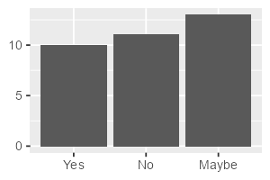

Any other comments or feedback

- My own research experience has been largely qualitative. While I took quantitative research in grad school, I’m not well versed in quantitate data analysis. I’m sure I need more than a “refresher”, but this may be a good starting place for me to determine where my knowledge gaps are and what is necessary to do my job well. Thanks for offering this!
- Thanks so much for doing this
- I look forward to participating!
- 15 minute consult would be great to help know what each class will focus on. Also, I know the idea of a guide to who is good at what in Dept of Plant Science and LAWR is not probably what y’all had in mind with this course, but that really would help me most in the long term. Almost all the expertise I know on campus are from when I did grad school 10 years ago. Those folks are starting to retire, or looking towards retirement. I know there’s lots of bright new minds in these departments, but I don’t know who is good at what, and who would be willing to be involved in extension field research. This could unlock all sorts of next-level stats that I’ll never find time to really master - Bayesian stuff, self-learning algorithms, stuff I don’t even know the name for or know about - as well as providing more applied research data for campus labs and strengthen our ANR-Davis connections.
- Could use skills refresher, and would like more familiarity with what tools to use in non-parametric situations.

Name

- Andre Biscaro
- Anita Oberholster
- Beatriz Nobua-Behrmann
- Brenna Aegerter
- CARMEN GISPERT
- Cindy Kron
- Claire Bjork
- Dorina M Espinoza
- Elina Niño
- Etaferahu Takele
- Franz Niederholzer
- George Zhuang
- Gerry Spinelli
- Hung
- Jaspreet Sidhu
- Jeff Mitchell
- John Harper
- JoLynn Miller
- Kat Jarvis-Shean
- Laura Snell
- Lucy Diekmann
- Michelle Leinfelder-Miles
- Nicholas Clark
- Nicole Marshall-Wheeler
- Rebecca Ozeran
- Roger Duncan
- Scott Stoddard
- Steven Swain
- Susie Kocher

Created with [Workshop Utilities for R](https://github.com/ucanr-igis/wrkshputils/) by [IGIS](https://igis.ucanr.edu/)